# QTM 151 - Quiz 1

## Submit as an HTML file

Print your name below

```python
# Write your answer here
print("Ellie Abbott")
```

```
Ellie Abbott
```

This quiz is open book

- You can use the lecture notes
- You will get partial credit for attempting the questions
- To get full credit, the code should your as intended
- You should NOT communicate with other students

Print the following message:

"I will abide by Emory's code of conduct"

```python
# Write your answer here:
print("I will abide by Emory's code of conduct")
```

```
I will abide by Emory's code of conduct
```

Import the libraries "numpy", "matplotlib.pytplot", and "pandas"

```python
# Write your answer here

import numpy as np
import matplotlib.pyplot as plt
import pandas as pd
```

(a) Transform a list of values and plot it

- Create an array with the following values

`vec_x = [-5,-3, 0, 10, 20, 40]`

- Create a new vector `vec_y` with the following formula

$\qquad y = [cos(x)]^2$

- Produce a scatter plot of "vec_y" against "vec_x"
- Label the axes and the title
- Change the color to "red", "green" or "purple" (you choose)

Hint: You can use the numpy functions

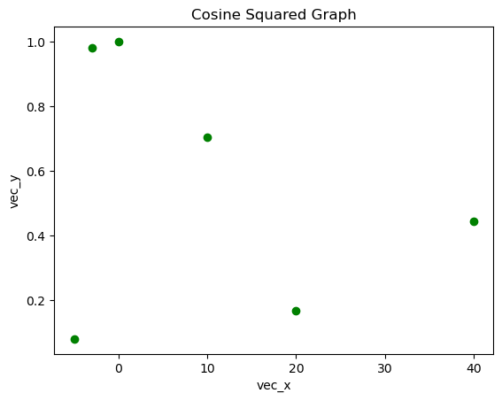

```python
# Write your answer here:

vec_x = np.array([-5, -3, 0, 10, 20, 40])

vec_y = ((np.cos(vec_x))**2)

plt.scatter(x=vec_x, y=vec_y, color = "green")
plt.ylabel("vec_y")
plt.xlabel("vec_x")
plt.title("Cosine Squared Graph")
```

(b) IF/ELSE statements

- Create two lists:

`list_fruits = ["apple","orange","pear","banana"]`  
`list_colors = ["blue","red","green","orange"]`

- Create a new variable `message = "orange"`
- Create an if/else that tests whether `message` is a  
  fruit and a color. Print a message if the test is true.

HINT: Use the "in" command to test whether an element is part  
of a list (see Lecture 4)

```python
# Write your answer here:
list_fruits = ["apple", "orange", "pear", "banana"]
list_colors = ["blue", "red", "green", "orange"]
message = "orange"


if message in list_fruits and message in list_colors:
    print(message + " is both a fruit and a color!")
```

```
orange is both a fruit and a color!
```

(c) Plot random variables ...

- Let $n = 1000$
- Generate "vec_x" from a Normal with (loc = 2, scale = 1, size = n)
- Generate "vec_z" from a chi square with (df = 2, size = n)
- Generate "vex_y" from a uniform with (low = 5,high = 10, size = n)
- Plot two scatter plots: (vec_y vs vec_x) and (vec_z vs vec_x)
  - Label the axes and title
  - Each graph should have a different title

To get full points, plot the histograms on a single row using the  
subplots syntax (see Lecture 6)

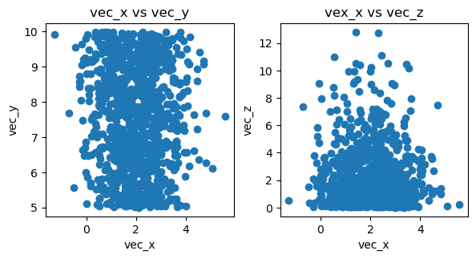

```python
# Write your answer here:

n = 1000
np.random.seed(3571)

vec_x = np.random.normal(loc = 2, scale = 1, size = n)
vec_z = np.random.chisquare(df = 2, size = n)
vec_y = np.random.uniform(low = 5, high = 10, size = n)

fig, list_subfig = plt.subplots (1, 2, figsize = (6,3))
plt.tight_layout()

list_subfig[0].scatter(x = vec_x, y = vec_y)
list_subfig[0].set_xlabel("vec_x")
list_subfig[0].set_ylabel("vec_y")
list_subfig[0].set_title("vec_x vs vec_y")

list_subfig[1].scatter(x = vec_x, y = vec_z)
list_subfig[1].set_xlabel("vec_x")
list_subfig[1].set_ylabel("vec_z")
list_subfig[1].set_title("vex_x vs vec_z")
```

(d) Create the following list of months

`list_months = ["August","February"]`  
`list_spring_semester = ["January","February", "March","April","May"]`

Create a for-loop that checks whether each element of `list_months`  
belongs to the spring semester. Create a message with this result. The output  
generated by your loop should look like this:

"August is NOT part of the Spring semester"  
"February is part of the Spring semester"

HINT: Use if/else statements inside the loop.  
You can use the command "in" (see Lecture 4) to test whether  
an element belongs to a list

```python
# Write your answer here:
list_months = ["August", "February"]
list_spring_semester = ["January", "February", "March", "April", "May"]

for month in list_months:
    if month in list_spring_semester:
        print(month + " is part of the Spring semester.")
    else:
        print(month + " is NOT part of the Spring semester")
```

```
August is NOT part of the Spring semester
February is part of the Spring semester.
```

(e) Loop through dfferent variables and plot

- Read the dataset "data_quiz/wdi_ageprop_2020.csv"
- Create a list of variable names with the following elements:

`list_varnames = ["percent_ages0to14","percent_ages15to64"]`

- Run a for loop that creates a histogram plot for each of the  
  variables on the list
  - Label the axes (the y-axis can be called "Frequency")
  - The loop should automatically create titles that look like this

    "Distribution for percent_ages0to14"  
    "Distribution for percent_ages15to64"

Note: This exercise tells you how much the proportion of the populaton  
in different ages varies across countries in 2020

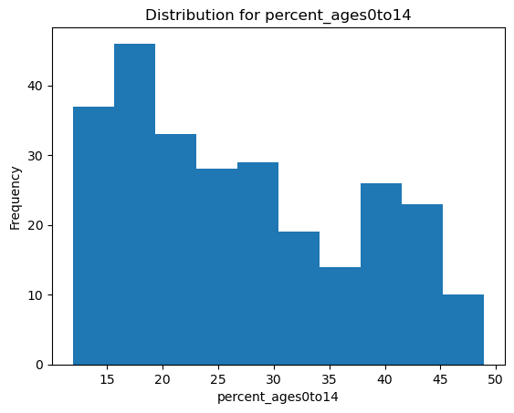

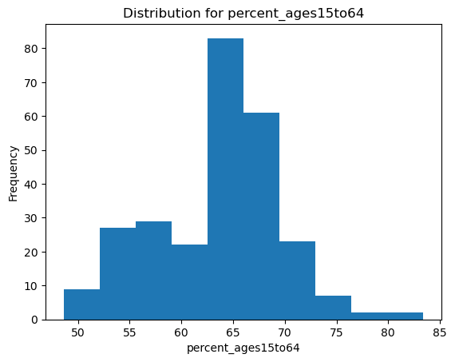

```python
# Write your answer here:

data = pd.read_csv("data_quiz/wdi_ageprop_2020.csv")
list_varnames = ["percent_ages0to14", "percent_ages15to64"]

for var in list_varnames:
    plt.hist(x = data[var])
    plt.xlabel(var)
    plt.ylabel("Frequency")
    plt.title("Distribution for " + var)
    plt.show()
```

(f) Run loop through different datasets and compute statistics

- Create a list with the ".csv" dataset names (including their relative subfolder "data_quiz/)
- Run a for-loop over the list of dataset names. Inside the loop:
  - Read the corresponding ".csv" dataset.
  - Print the mean of the variable "percent_ages0to14" in  
    each dataset

Note: This exercise tells you how much the proportion of the  
population that is between 0 and 14 has varied  
from year to year using real data from the World Development Index.

```python
# Write your answer here:

list_datasets = ["data_quiz/wdi_ageprop_1980.csv", "data_quiz/wdi_ageprop_2000.csv", "data_quiz/wdi_ageprop_2020.csv"]

for name in list_datasets:
    data = pd.read_csv(name)
    print(np.mean(data["percent_ages0to14"]))
```

```
36.82095078354717
32.17265501184906
26.90657125728302
```